# American Community Survey 2013-17 Project Report

## **Year wise - Most popular field of engineering.**

This section focusses on finding the most popular field of engineering i.e Number of people in particular field per year. Note: 2014 year data is compared with 2013 (Total count of people), 2015 with 2014, 2016 with 2015 and similarly 2017 with 2016.

```r
library(dplyr)
popular_field_by_year <- data_for_analysis %>%
  dplyr::filter(FOD1P==2401 | FOD1P==2402 | FOD1P==2403| FOD1P==2404| FOD1P==2405| FOD1P==2406|  FOD1P==2407| FOD1P==2408| FOD1P==2410 | FOD1P==2418) %>%
  dplyr::group_by(FOD1P,year) %>%
  dplyr::summarise(total = sum(PWGTP))

year_2013 <- popular_field_by_year %>%
  dplyr::filter(year==2013)

popular_field_by_year$FOD1P <- factor(popular_field_by_year$FOD1P)
levels(popular_field_by_year$FOD1P)[levels(popular_field_by_year$FOD1P)==2401] <- "Aerospace"
levels(popular_field_by_year$FOD1P)[levels(popular_field_by_year$FOD1P)==2402] <- "Biological"
levels(popular_field_by_year$FOD1P)[levels(popular_field_by_year$FOD1P)==2403] <- "Architectural"
levels(popular_field_by_year$FOD1P)[levels(popular_field_by_year$FOD1P)==2404] <- "Biomedical"
levels(popular_field_by_year$FOD1P)[levels(popular_field_by_year$FOD1P)==2405] <- "Chemical"
levels(popular_field_by_year$FOD1P)[levels(popular_field_by_year$FOD1P)==2406] <- "Civil"
levels(popular_field_by_year$FOD1P)[levels(popular_field_by_year$FOD1P)==2407] <- "Computer"
levels(popular_field_by_year$FOD1P)[levels(popular_field_by_year$FOD1P)==2408] <- "Electrical"
levels(popular_field_by_year$FOD1P)[levels(popular_field_by_year$FOD1P)==2410] <- "Environmental"
levels(popular_field_by_year$FOD1P)[levels(popular_field_by_year$FOD1P)==2418] <- "Nuclear Eng."


spreaded_data <- popular_field_by_year %>%
  spread(year,total)

#NUmber's in table shows people count.
#Upward Arrow with green color indicates that total count of people has been increased from previous year. On the other hand, Downward arrow with red color indicates that total count of people has decreased from the previous year.
formattable(spreaded_data,list(
  `FOD1P` = formatter("span",
                        style = ~ style(color = "blue",font.weight = "bold"),
                        x~icontext(ifelse(x=="Electrical" ,"star",""),x)),
   `2014`= formatter("span", style = ~ style(color = ifelse(`2014` > `2013`, "green", "red")),~ icontext(ifelse(`2014` >`2013`,"arrow-up", "arrow-down"), `2014`)),
  `2015`= formatter("span", style = ~ style(color = ifelse(`2015` > `2014`, "green", "red")),~ icontext(ifelse(`2015` >`2014`,"arrow-up", "arrow-down"), `2015`)),
  `2016`= formatter("span", style = ~ style(color = ifelse(`2016` > `2015`, "green", "red")),~ icontext(ifelse(`2016` >`2015`,"arrow-up", "arrow-down"), `2016`)),
  `2017`= formatter("span", style = ~ style(color = ifelse(`2017` > `2016`, "green", "red")),~ icontext(ifelse(`2017` >`2016`,"arrow-up", "arrow-down"), `2017`))

                        ))
```

| FOD1P | 2013 | 2014 | 2015 | 2016 | 2017 |
| --- | --- | --- | --- | --- | --- |
| Aerospace | 20274 | 21596 | 22535 | 23421 | 24177 |
| Biological | 8582 | 9085 | 11387 | 11244 | 11828 |
| Architectural | 4327 | 4078 | 3640 | 4131 | 4542 |
| Biomedical | 9362 | 9258 | 10059 | 13252 | 13221 |
| Chemical | 60804 | 59686 | 61967 | 66943 | 69613 |
| Civil | 95243 | 100149 | 103522 | 106051 | 109239 |
| Computer | 51610 | 53072 | 57547 | 63270 | 67851 |
| Electrical | 204612 | 204654 | 214507 | 218443 | 234911 |
| Environmental | 4737 | 5700 | 5609 | 5581 | 5997 |
| Nuclear Eng. | 3312 | 3271 | 4023 | 4065 | 4552 |

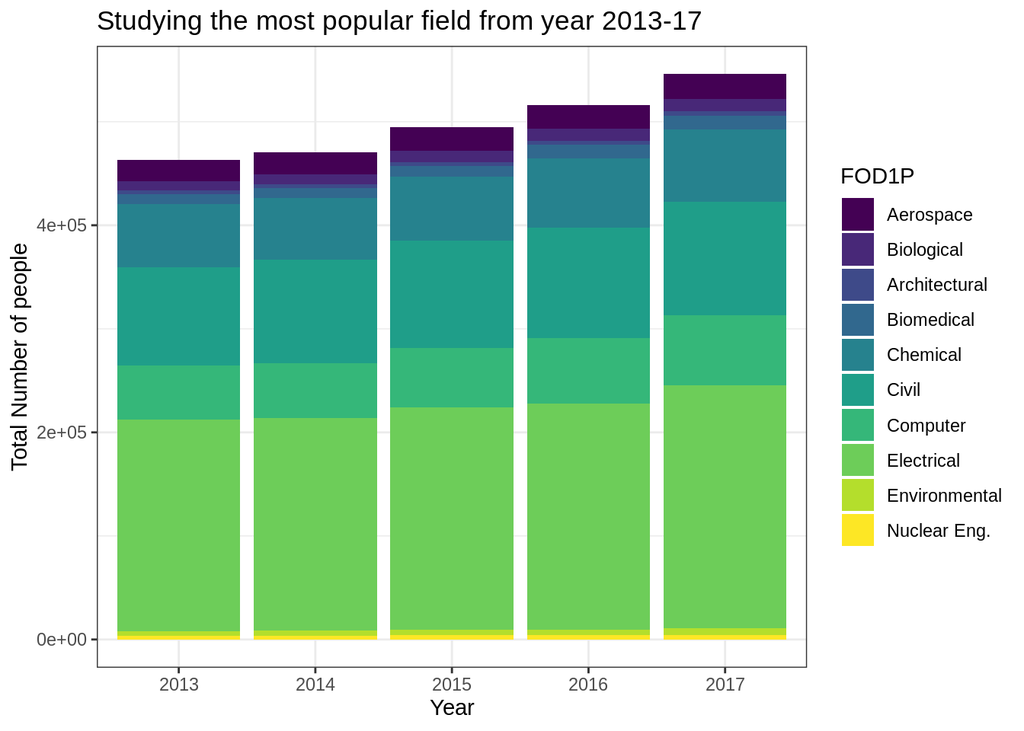

```r
ggplot(popular_field_by_year, aes(fill=FOD1P, y=total, x=factor(year))) +
    geom_bar(position="stack", stat="identity") +
    scale_fill_viridis(discrete = T) +
    ggtitle("Studying the most popular field from year 2013-17")+theme_bw()+labs(
      x="Year",
      y="Total Number of people"
    )
```

Upward Arrow with green color indicates that total count of people has been increased from previous year. On the other hand, Downward arrow with red color indicates that total count of people has decreased from the previous year.

Summary and Interpretation for above tabular data:

- From 2013 to 2017, no of people in “Aerospace”,“Civil”,“Computer” and “Electrical” has continously increased.
- “Electrical Engineering” was the most popular field according to the survey data
- Nuclear Eng. was the least popular amongs all other engineering field

## **Income Group Prediction Using Support Vector Machines**

This section of the project focusses on predictiing Income group of person in total 5 “Categories”.

After trying Multi Linear and Polynomial Regression, the model had very low accuracy and hence I tried to classify Income rather than predict the actual continous Income.

### **Data Preprocessing- Making data ready to train SVM model!**

```r
#Removing Income with less than 0.

data_without_negtive_Income <- data_for_analysis %>%
  filter(Income_with_ADJINC>0)

summary(data_without_negtive_Income$Income_with_ADJINC)

#Making new column "Income_Group"
data_with_income_groups <- data_without_negtive_Income %>%
  dplyr::mutate(Income_Group = case_when(
    Income_with_ADJINC<20000 ~"Very Low",
    Income_with_ADJINC>=20000 & Income_with_ADJINC<30000 ~"Low",
    Income_with_ADJINC>=30000 & Income_with_ADJINC<70000   ~"Average",
    Income_with_ADJINC>=70000 & Income_with_ADJINC<90000 ~"Above Average",
    Income_with_ADJINC>=90000 ~"High"

  ))


levels(data_with_income_groups$SCHL)[levels(data_with_income_groups$SCHL)=="Bachelors"] <- 21
levels(data_with_income_groups$SCHL)[levels(data_with_income_groups$SCHL)=="Master's"] <- 22
levels(data_with_income_groups$SCHL)[levels(data_with_income_groups$SCHL)=="Professional Degree after Bachelor's"] <- 23
levels(data_with_income_groups$SCHL)[levels(data_with_income_groups$SCHL)=="Doctorate"] <- 24

data_with_income_groups$Income_Group <- factor(data_with_income_groups$Income_Group)
levels(data_with_income_groups$Income_Group)[levels(data_with_income_groups$Income_Group)=="Very Low"] <- 1
levels(data_with_income_groups$Income_Group)[levels(data_with_income_groups$Income_Group)=="Low"] <- 2
levels(data_with_income_groups$Income_Group)[levels(data_with_income_groups$Income_Group)=="Average"] <- 3
levels(data_with_income_groups$Income_Group)[levels(data_with_income_groups$Income_Group)=="Above Average"] <- 4
levels(data_with_income_groups$Income_Group)[levels(data_with_income_groups$Income_Group)=="High"] <- 5
```

### **Splitting up Training and Tesing datasets using createDataPartition**

```r
library(caret)
set.seed(3456)
# 75% => Training Dataset and 25% => Testing Dataset
trainIndex <- createDataPartition(data_with_income_groups$Income_Group, p = .75,
                                  list = FALSE,
                                  times = 1)

train_dataset <- data_with_income_groups[trainIndex,]
test_dataset <- data_with_income_groups[-trainIndex,]
```

```r
library(caTools)
library(e1071)

train_dataset <-  train_dataset %>%
  dplyr::filter(year==2017) %>%
  dplyr::select(ST,CIT,COW,AGEP,SEX,FOD1P,SCHL,RAC1P,Income_Group)

test_dataset <-  test_dataset %>%
  dplyr::filter(year==2017) %>%
  dplyr::select(ST,CIT,COW,AGEP,SEX,FOD1P,SCHL,RAC1P,Income_Group)


test_dataset$ST <-factor(test_dataset$ST)
test_dataset$CIT <-factor(test_dataset$CIT)
test_dataset$COW <-factor(test_dataset$COW)
test_dataset$SEX <-factor(test_dataset$SEX)
test_dataset$FOD1P <-factor(test_dataset$FOD1P)
test_dataset$SCHL <-factor(test_dataset$SCHL)
test_dataset$RAC1P <-factor(test_dataset$RAC1P)
test_dataset$Income_Group <-factor(test_dataset$Income_Group)

train_dataset$ST <-factor(train_dataset$ST)
train_dataset$CIT <-factor(train_dataset$CIT)
train_dataset$COW <-factor(train_dataset$COW)
train_dataset$SEX <-factor(train_dataset$SEX)
train_dataset$FOD1P <-factor(train_dataset$FOD1P)
train_dataset$SCHL <-factor(train_dataset$SCHL)
train_dataset$RAC1P <-factor(train_dataset$RAC1P)
train_dataset$Income_Group <-factor(train_dataset$Income_Group)

saveRDS(train_dataset,"train_dataset.rds")
saveRDS(test_dataset,"test_dataset.rds")
```

### **Training Classifier**

```r
set.seed(123)
classifier = svm(formula = Income_Group ~ .,
data = train_dataset,
type = 'C-classification',
gamma = 100
)
saveRDS(classifier,"classifier.rds")
```

```r
classifier <- readRDS("classifier.rds")
sample_n(test_dataset, n=10000)
y_train_pred <- predict(classifier, newdata=train_dataset[-9])
y_test_pred = predict(classifier, newdata=test_dataset[-9])
```

**Test Dataset- Performance**

```r
test_dataset <- readRDS("test_dataset.rds")
y_test_pred <- readRDS("y_test_pred.rds")
svm_y_test_sample_cm <- confusionMatrix(y_test_pred,test_dataset$Income_Group)
saveRDS(svm_y_test_sample_cm,"svm_y_test_sample_cm.rds")
```

```r
svm_y_test_sample_cm <-readRDS("svm_y_test_sample_cm.rds")
svm_y_test_sample_cm
```

```
## Confusion Matrix and Statistics
##
##                Reference
## Prediction      Above Average Average  High   Low Very Low
##   Above Average             0       0     0     0        0
##   Average               11932   43700 14591  9647    16681
##   High                   7632   13063 31763  2609     3945
##   Low                       0       0     0     0        0
##   Very Low                 13     106    26    68      245
##
## Overall Statistics
##
##                Accuracy : 0.4852
##                  95% CI : (0.4828, 0.4877)
##     No Information Rate : 0.3645
##     P-Value [Acc > NIR] : < 2.2e-16
##
##                   Kappa : 0.222
##
##  Mcnemar's Test P-Value : NA
##
## Statistics by Class:
##
##                      Class: Above Average Class: Average Class: High
## Sensitivity                        0.0000         0.7684      0.6848
## Specificity                        1.0000         0.4670      0.7515
## Pos Pred Value                        NaN         0.4526      0.5382
## Neg Pred Value                     0.8745         0.7786      0.8493
## Prevalence                         0.1255         0.3645      0.2973
## Detection Rate                     0.0000         0.2801      0.2036
## Detection Prevalence               0.0000         0.6188      0.3782
## Balanced Accuracy                  0.5000         0.6177      0.7182
##                      Class: Low Class: Very Low
## Sensitivity             0.00000        0.011739
## Specificity             1.00000        0.998424
## Pos Pred Value              NaN        0.534934
## Neg Pred Value          0.92101        0.867411
## Prevalence              0.07899        0.133770
## Detection Rate          0.00000        0.001570
## Detection Prevalence    0.00000        0.002936
## Balanced Accuracy       0.50000        0.505081
```

**Sample Training Dataset - Performance**

```r
classifier<- readRDS("classifier.rds")
train_dataset <- readRDS("train_dataset.rds")
sample_train <- sample_n(train_dataset,25000)
y_sample_train_pred <- predict(classifier,sample_train[-9])
svm_y_train_sample_cm <- confusionMatrix(y_sample_train_pred,sample_train$Income_Group)
saveRDS(svm_y_train_sample_cm,"svm_y_train_sample_cm.rds")
```

```r
svm_y_train_sample_cm <-readRDS("svm_y_train_sample_cm.rds")
svm_y_train_sample_cm
```

```
## Confusion Matrix and Statistics
##
##                Reference
## Prediction      Above Average Average High  Low Very Low
##   Above Average             0       0    0    0        0
##   Average                1895    6960 2487 1497     2655
##   High                   1239    2120 5034  401      646
##   Low                       0       0    0    0        0
##   Very Low                  1      10    3   10       42
##
## Overall Statistics
##
##                Accuracy : 0.4814
##                  95% CI : (0.4752, 0.4877)
##     No Information Rate : 0.3636
##     P-Value [Acc > NIR] : < 2.2e-16
##
##                   Kappa : 0.2151
##
##  Mcnemar's Test P-Value : NA
##
## Statistics by Class:
##
##                      Class: Above Average Class: Average Class: High
## Sensitivity                        0.0000         0.7657      0.6691
## Specificity                        1.0000         0.4636      0.7479
## Pos Pred Value                        NaN         0.4492      0.5333
## Neg Pred Value                     0.8746         0.7759      0.8400
## Prevalence                         0.1254         0.3636      0.3010
## Detection Rate                     0.0000         0.2784      0.2014
## Detection Prevalence               0.0000         0.6198      0.3776
## Balanced Accuracy                  0.5000         0.6146      0.7085
##                      Class: Low Class: Very Low
## Sensitivity             0.00000         0.01256
## Specificity             1.00000         0.99889
## Pos Pred Value              NaN         0.63636
## Neg Pred Value          0.92368         0.86761
## Prevalence              0.07632         0.13372
## Detection Rate          0.00000         0.00168
## Detection Prevalence    0.00000         0.00264
## Balanced Accuracy       0.50000         0.50573
```

### **Intrepretation of SVM-Model on Testing and Training Dataset**

- Using confusion matrix, we can see that SVM model had almost same accuracy(48%) for sample Training and Test dataset. But it might differ for whole training dataset. Although, this is not a great model, It can be improved using hyper-parameter optimization techniques like GridSearchCV, changinh kernel type,etc.
- Using “Statistics by Class”, we have several parameters which tells how different categories/levels are predicted. For example, “Balanced Accuracy”, Class: High had the highest and balanced actual TRUE predictions.
- One important thing to note is that, this model performed worst in predicting classes “Above Average” and “Low”. But did well in predicting classes like “Average” and “High”
- Although this model cannot be used in real-life, but can be used for people with Average and High Income.

## **Income_Group prediction using Artificial Neural Network**

In order to built better classification model, I also tried using ANN-Artificial Neural Network.

```r
ann_classification_model_income <- train(Income_Group ~ .,
                                         data = train_dataset,
                                         method = "nnet",
                                         maxit=50
                                         )
save(ann_classification_model_income)

train_pred_ann <- predict(ann_classification_model_income,train_dataset[-9])
test_prediction_ann <- predict(ann_classification_model_income,test_dataset[-9])
```

### **Evaluating Confusion matrix on Testing dataset using trained ANN.**

```r
test_dataset <- readRDS("test_dataset.rds")

train_pred_ann <- readRDS("train_pred_ann.rds")
test_prediction_ann <- readRDS("test_prediction_ann.rds")

y_test_cm_ann <- confusionMatrix(test_prediction_ann,test_dataset$Income_Group)
y_test_cm_ann
```

```
## Confusion Matrix and Statistics
##
##                Reference
## Prediction      Above Average Average  High   Low Very Low
##   Above Average             0       0     0     0        0
##   Average               10064   38661 12885  8620    15547
##   High                   9513   18208 33495  3704     5324
##   Low                       0       0     0     0        0
##   Very Low                  0       0     0     0        0
##
## Overall Statistics
##
##                Accuracy : 0.4625
##                  95% CI : (0.46, 0.465)
##     No Information Rate : 0.3645
##     P-Value [Acc > NIR] : < 2.2e-16
##
##                   Kappa : 0.1926
##
##  Mcnemar's Test P-Value : NA
##
## Statistics by Class:
##
##                      Class: Above Average Class: Average Class: High
## Sensitivity                        0.0000         0.6798      0.7222
## Specificity                        1.0000         0.5248      0.6648
## Pos Pred Value                        NaN         0.4507      0.4768
## Neg Pred Value                     0.8745         0.7408      0.8498
## Prevalence                         0.1255         0.3645      0.2973
## Detection Rate                     0.0000         0.2478      0.2147
## Detection Prevalence               0.0000         0.5498      0.4502
## Balanced Accuracy                  0.5000         0.6023      0.6935
##                      Class: Low Class: Very Low
## Sensitivity             0.00000          0.0000
## Specificity             1.00000          1.0000
## Pos Pred Value              NaN             NaN
## Neg Pred Value          0.92101          0.8662
## Prevalence              0.07899          0.1338
## Detection Rate          0.00000          0.0000
## Detection Prevalence    0.00000          0.0000
## Balanced Accuracy       0.50000          0.5000
```

Accuracy =46% which is even lesser than previous SVM classification model.

This is not the results I was expected, Using confusion matrix, we can see that ANN is not able to accurately classify classes like “Above Average”, “Low” and “Very Low”. Maybe because of lesser no of people having that Income_Group. So, I think, the model is underfitted for some levels or classes like “very low” and “above average”, even though training time was approximately: 13 hours.

## **What features influenced people purchasing Insurance from a private company ? - Using ANN**

This section aims to analyze which input features affects the most for buying an insurance from a private company(H1NS2) and predict whether a person is going to buy an insurance from a private company. I thought this can be usefull for an insurance company to target specific people which are likely to purchase an insurance.

```r
cols <- c("AGEP","COW","PINCP","ST","JWTR","CIT","HINS1","HINS2")

df <-   fread("/home/ayush/Downloads/csv_pus/psam_pusa.csv",select=cols)
df_b <- fread("/home/ayush/Downloads/csv_pus/psam_pusb.csv",select=cols)
df_c <- fread("/home/ayush/Downloads/csv_pus/psam_pusc.csv",select=cols)
df_d <- fread("/home/ayush/Downloads/csv_pus/psam_pusd.csv",select=cols)

data_merged <- rbind(df,df_b,df_c,df_d)
insurance_classification <- tbl_df(data_merged)
insurance_classification <- na.omit(insurance_classification)

rm(df,df_b,df_c,df_d)

insurance_classification <- insurance_classification %>%
  filter(ST=="6", AGEP>19)

insurance_classification$HINS1 <- factor(insurance_classification$HINS1)
insurance_classification$HINS2 <- factor(insurance_classification$HINS2)
insurance_classification$COW <- factor(insurance_classification$COW)
insurance_classification$CIT <- factor(insurance_classification$CIT)

install.packages('e1071', dependencies=TRUE)

set.seed(1414)
insurance_model <- train(HINS2 ~ .,
                   data = insurance_classification,
                   method = "nnet")

insurance_classification<- within(insurance_classification, rm(ST))
saveRDS(insurance_model,"insurancemodel.rds")
```

### **Graphical Representation of trained ANN**

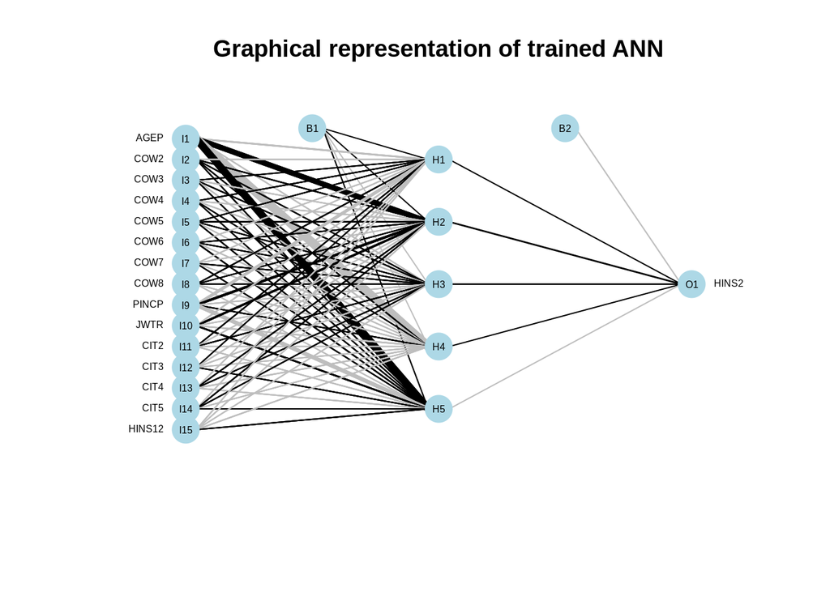

```r
insurance_model <- readRDS("insurancemodel.rds")
plotnet(insurance_model$finalModel,circle_cex=3,cex_val=0.5,y_names = "HINS2",max_sp=TRUE)
title("Graphical representation of trained ANN")
```

### **Feature Importance Graph**

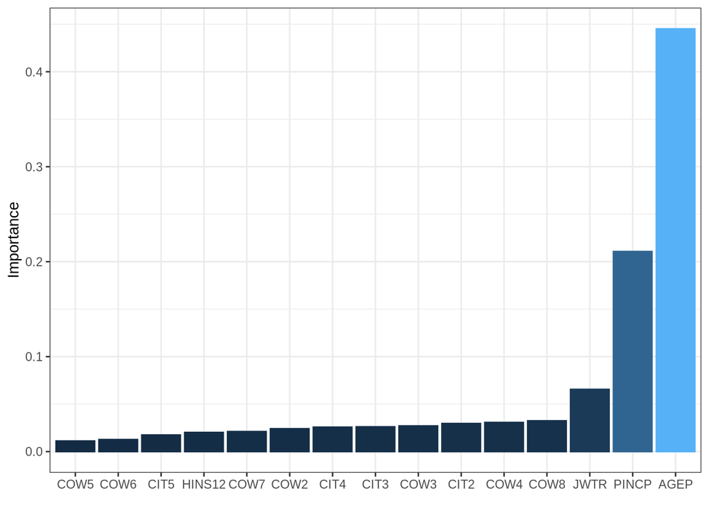

```r
garson(insurance_model$finalModel)
```

```r
# We can also use plot(varImp()) function instead of garson, Garson function just plot importance factor in bar graph form which is easy to understand.
```

From the graph, we can see that **“AGE” , “Means of Transportation” and “Income”** affects the most according to model. Hence, an insurance company can use these three variables to predict whether the person is going to buy insurance or not.

### **Summary of trained ANN**

Final Accuracy of model was: 87.5 % which is really better than previous trained Machine Learning models. Final size was 5 with 2 classes in target variable. (1. Yes 2. No)

```r
insurance_model
```

```
## Neural Network
##
## 805500 samples
##      6 predictor
##      2 classes: '1', '2'
##
## No pre-processing
## Resampling: Bootstrapped (25 reps)
## Summary of sample sizes: 805500, 805500, 805500, 805500, 805500, 805500, ...
## Resampling results across tuning parameters:
##
##   size  decay  Accuracy   Kappa
##   1     0e+00  0.8747586  0.00000000
##   1     1e-04  0.8747586  0.00000000
##   1     1e-01  0.8752606  0.01307286
##   3     0e+00  0.8752032  0.01289698
##   3     1e-04  0.8747487  0.00020605
##   3     1e-01  0.8765056  0.05105924
##   5     0e+00  0.8762514  0.03691558
##   5     1e-04  0.8775110  0.07004265
##   5     1e-01  0.8759048  0.08890060
##
## Accuracy was used to select the optimal model using the largest value.
## The final values used for the model were size = 5 and decay = 1e-04.
```